# 2024_anticoagulation

Aaron Mittel

2026-04-09

# Aims and Hypotheses

- **Aim 1**: Determine the prevalence and differentiating features of patients with versus without aPTT-anti-Xa discordance among patients receiving ECMO at CUIMC in 2024.

*Hypothesis 1*: Discordance is a relatively common, yet under appreciated phenomenon, and varies by geographic location of care and patient attributes including demographics, severity of illness, and underlying disease process.

- **Aim 2**: Determine the implications of discordance between aPTT and anti-Xa on hemorrhagic and thrombotic complications in a cohort of patients who received ECMO at CUIMC in 2024.

*Hypothesis 2*: Discordance between aPTT and anti-Xa indicates the presence of coagulation system pathophysiology which is a risk factor for development of hemorrhage and thrombosis.

**Classic systemic anticoagulation goals, anti-Xa vs aPTT, at NYP:**

- 0.3 - 0.7 vs 51 - 83

**Typical anti-Xa goal vs aPTT goals among heparinized ECMO patients:**

- 0.1 - 0.3 vs 35 - 50 (LOW GOAL)
- 0.2 - 0.5 vs 45 - 65 (CLASSIC GOAL)

Source: NYP GUIDLINE “UNFRACTIONATED HEPARIN INTRAVENOUS (IV) DOSING AND MONITORING FOR ADULT INPATIENTS RECEIVING EXTRACORPOREAL MEMBRANE OXYGENATION (ECMO)” Approved Dec 2022

# Methods:

Only first ECMO run used.

ECMO duration: Dr. Connie Nguyen manually reviewed heparin-exposed patients’ EMRs in June 2025 to identify true ECMO time off, as initial data review identified some labs that were drawn while on heparin but after the patient was off ECMO. The variable “time_off” in the original data was obtained from ELSO sources. Per Dr. Nguyen’s review, if her evaluation of ECMO stop time was within 4 hours of ELSO-derived time_off, then the actual true time off was deemed as that known by ELSO. If there was a greater than 4 hour discrepancy, a new time_off_true value was recorded.

Lab cutoffs:

- if aPTT <20.0 - made 0
- if aPTT >180 - made 180
- if anti-Xa <0.04 or <0.1 - made 0
- if anti-Xa >2.00 - made 2.0
- if data is duplicated at a specific timepoint (e.g. 2 lab samples, exact same result time but different values), then taking the mean of the two exact same-timed values

Hyperbilirubinemia can artifactually elevate anti-Xa (colorimetric assay). Jaundice threshold is 2 - 3 mg/dL total bilirubin. Upper limit of normal total bilirubin at NYP-CUIMC is 1.2 mg/dL.

Bilirubin is measured in separate tubes compared to aPTT, anti-Xa, INR, and fibrinogen. As hyperbilirubinemia can impact assessment of anti-Xa but also may not change rapidly from one moment to another, we accounted for total bilirubin by computing the `nearest_bilirubin` value within 24 hours of any aPTT. (aPTT chosen as it was the most frequently measured coagulation lab).

Likewise, platelet count is measured in separate tubes compared to aPTT, anti-Xa, INR, and fibrinogen. Thrombocytopenia can impact discordance (PMID 38725133). Thus, we computed `nearest_platelet` value within 24 hours of any aPTT, in a manner comparable to that of `nearest_bilirubin`.

COMPLICATIONS: all complications reviewed were documented during ECMO duration, with exception of clinically significant bleeding and thrombotic complications which were manually assessed by Connie and Phil as follows:

- DVT/PE_1_time_and_date
- DVT/PE_2_time_and_date
- DVT/PE_3_time_and_date
- DVT/PE_4_time_and_date
- Ischemic_stroke_1_time_and_date
- Ischemic_stroke_2_time_and_date
- Ischemic_stroke_3_time_and_date
- Acute_limb_ischemia_1_time_and_date
- Acute_limb_ischemia_2_time_and_date
- Acute_limb_ischemia_3_time_and_date
- GI bleeding - present on CTA and confirmed via endoscopy
- ICH - based on imaging findings

# Basic Lab Counts and Scatterplot visualization among ECMO paients who received heparin exposed

count of distinct MRNs of patients exposed to heparin TOTAL

| n |
| --- |
| 165 |

counts of MRNs of patients exposed to heparin by location TOTAL - these do not all have anti-Xa and aPTT matched pairs FYI; counts between distinct MRNs and department_name may not match as some patients move between departments

| department_name | n |
| --- | --- |
| MIL 5 CTICU | 76 |
| MIL 5 CCU | 41 |
| MIL 4 MICU A | 31 |
| HRT CARDIAC CARE | 25 |
| MIL OPERATING ROOM | 5 |
| MIL 4 SICU | 1 |
| MIL CARDIAC CATH | 1 |
| GBG 4 W CT ICU | 1 |

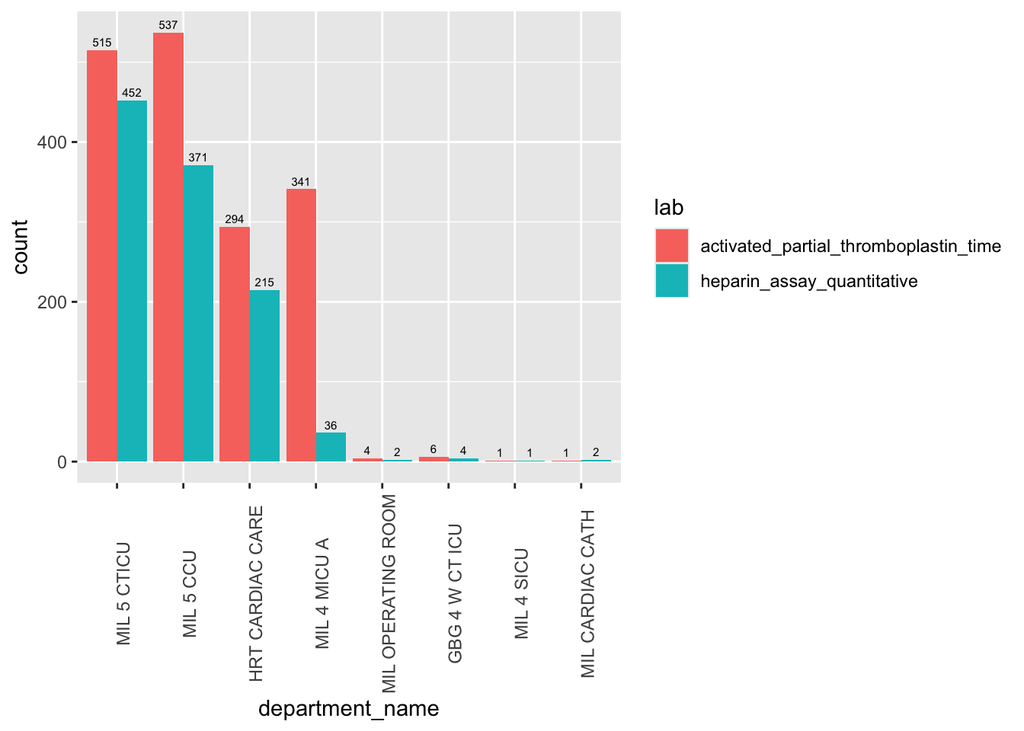

count of distinct MRNs of patients exposed to heparin who have TIME-MATCHED anti-Xa and aPTT pairs

| n |
| --- |
| 113 |

counts of distinct MRNs by location of patients exposed to heparin who have TIME-MATCHED anti-Xa and aPTT pairs; counts between distinct MRNs and department_name may not match as some patients move between departments

| department_name | n |
| --- | --- |
| MIL 5 CTICU | 56 |
| MIL 5 CCU | 31 |
| HRT CARDIAC CARE | 22 |
| MIL 4 MICU A | 6 |
| MIL 4 SICU | 1 |
| MIL OPERATING ROOM | 1 |
| MIL CARDIAC CATH | 1 |
| GBG 4 W CT ICU | 1 |

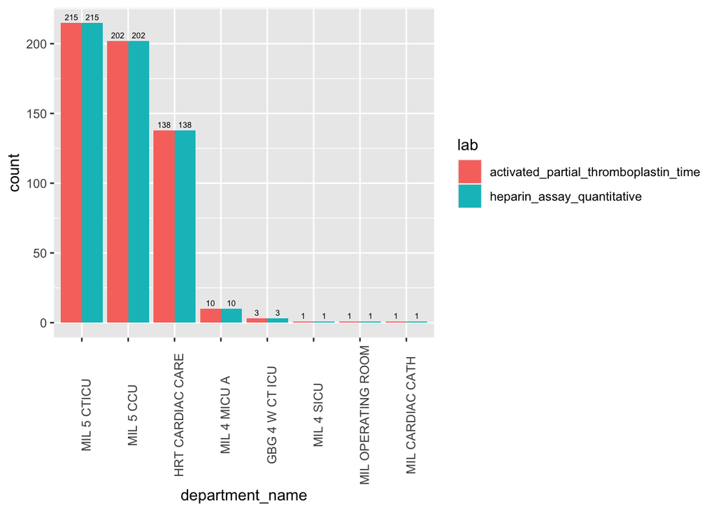

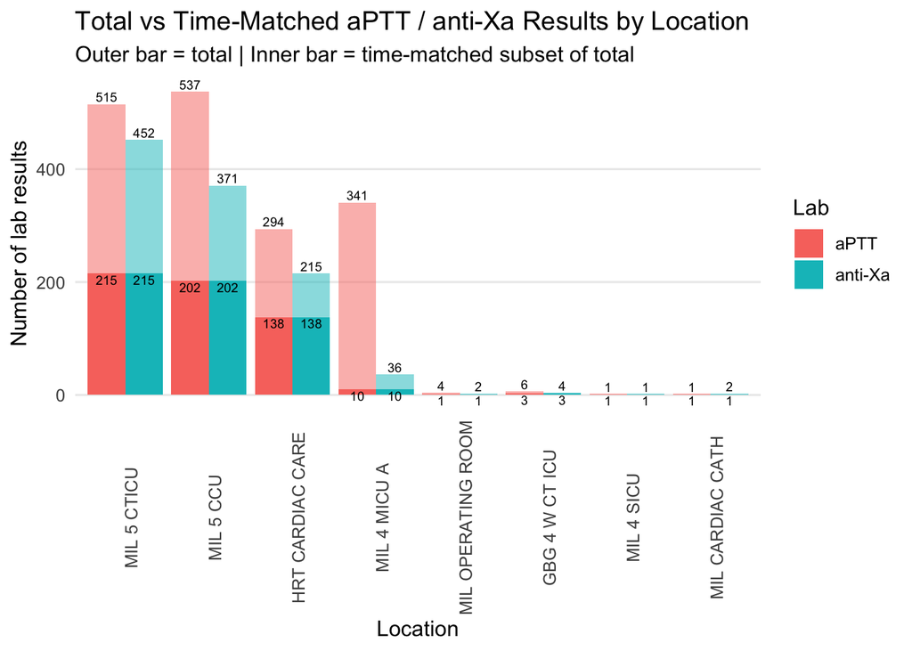

```
## # A tibble: 1 × 1
##   correlation
##         <dbl>
## 1       0.740
```

[interactive chart not shown]

# Polynomial Fitting

This fits a second degree polynomial on aPTT and accounts for repeated measures per patient (i.e. multiple labs per individual patient) by including a random intercept for each patient. This is important as the repeated measures per patient are not independent - the labs are dependent on the baseline values (and the baseline anti-Xa between patients who have the same aPTT may not be the same, or vice versa).

**95% prediction interval chosen to balance sensitivity and specificity.**

[interactive chart not shown]

list of MRNs with aPTT > antiXa

| x |
| --- |
| 1001491594 |
| 1002467250 |
| 1006905710 |
| 1007129753 |
| 1009477257 |
| 1010147999 |
| 1011043983 |
| 1011077110 |
| 1100547209 |
| 1102078503 |
| 1201199342 |
| 1400032239 |
| 1400969240 |
| 1401183967 |
| 1401327774 |
| 1401468984 |
| 1401639110 |
| 1401766288 |

list of MRNs with aPTT < antiXa

| x |
| --- |
| 1001491594 |
| 1003642179 |
| 1009544965 |
| 1010696012 |
| 1101397979 |
| 1102216636 |
| 1201555171 |
| 1401554006 |
| 1401591974 |
| 1401611898 |
| 1401682296 |
| 1401683148 |
| 1401689750 |
| 1401696145 |
| 1401697961 |
| 1401707171 |
| 1401796928 |
| 1401848048 |
| 1401991907 |

aPTT > antiXa, time-matched pairs

| mrn | lab_result_time | activated_partial_thromboplastin_time | heparin_assay_quantitative |
| --- | --- | --- | --- |
| 1001491594 | 2024-08-24 22:45:00 | 96.9 | 0.36 |
| 1002467250 | 2024-12-12 18:30:00 | 63.5 | 0.26 |
| 1006905710 | 2024-10-10 18:02:00 | 71.3 | 0.07 |
| 1006905710 | 2024-10-11 06:23:00 | 56.2 | 0.16 |
| 1007129753 | 2024-04-12 06:13:00 | 43.5 | 0.10 |
| 1007129753 | 2024-04-12 18:41:00 | 42.9 | 0.10 |
| 1007129753 | 2024-04-13 06:08:00 | 43.8 | 0.10 |
| 1007129753 | 2024-04-13 18:00:00 | 45.2 | 0.10 |
| 1009477257 | 2024-12-02 15:04:00 | 41.9 | 0.09 |
| 1010147999 | 2024-02-20 18:35:00 | 60.3 | 0.10 |
| 1010147999 | 2024-02-21 12:35:00 | 52.6 | 0.10 |
| 1011043983 | 2024-06-17 17:05:00 | 75.4 | 0.33 |
| 1011043983 | 2024-06-17 22:39:00 | 93.2 | 0.37 |
| 1011043983 | 2024-06-18 04:34:00 | 93.8 | 0.36 |
| 1011043983 | 2024-06-18 09:40:00 | 106.5 | 0.40 |
| 1011043983 | 2024-06-18 16:00:00 | 103.4 | 0.43 |
| 1011043983 | 2024-06-18 22:46:00 | 89.5 | 0.37 |
| 1011043983 | 2024-06-19 05:51:00 | 106.0 | 0.43 |
| 1011043983 | 2024-06-19 11:46:00 | 122.7 | 0.46 |
| 1011043983 | 2024-06-20 11:59:00 | 104.6 | 0.48 |
| 1011077110 | 2024-05-20 06:06:00 | 58.1 | 0.14 |
| 1011077110 | 2024-05-21 06:42:00 | 70.1 | 0.23 |
| 1100547209 | 2024-05-02 14:06:00 | 119.4 | 0.60 |
| 1102078503 | 2025-01-07 10:13:00 | 36.9 | 0.04 |
| 1201199342 | 2024-09-26 12:28:00 | 76.7 | 0.34 |
| 1400032239 | 2024-03-18 23:46:00 | 45.6 | 0.10 |
| 1400969240 | 2024-10-13 23:20:00 | 39.7 | 0.05 |
| 1400969240 | 2024-10-14 18:13:00 | 38.5 | 0.06 |
| 1401183967 | 2024-03-30 18:34:00 | 102.0 | 0.30 |
| 1401327774 | 2024-11-03 03:56:00 | 122.1 | 0.38 |
| 1401327774 | 2024-11-03 11:13:00 | 94.3 | 0.38 |
| 1401327774 | 2024-11-03 19:02:00 | 63.2 | 0.22 |
| 1401468984 | 2024-02-24 07:04:00 | 42.8 | 0.10 |
| 1401468984 | 2024-02-27 18:47:00 | 55.3 | 0.20 |
| 1401639110 | 2024-08-20 06:59:00 | 64.4 | 0.16 |
| 1401766288 | 2024-07-31 06:09:00 | 60.3 | 0.21 |

```
## # A tibble: 1 × 2
##   mean_aptt mean_antiXa
##       <dbl>       <dbl>
## 1      72.3       0.241
```

aPTT > antiXa, time-matched pairs, counts of typical concordance if classic anticoagulation goals at CUIMC used

| concordance_classic_simple | n |
| --- | --- |
| concordant | 13 |
| discordant aPTT above antiXa | 22 |
| high aPTT low antiXa | 1 |

aPTT > antiXa, time-matched pairs, counts of typical concordance if low anticoagulation goals at CUIMC used

| concordance_low_simple | n |
| --- | --- |
| concordant | 20 |
| discordant aPTT above antiXa | 15 |
| high aPTT low antiXa | 1 |

aPTT < antiXa, time-matched pairs

| mrn | lab_result_time | activated_partial_thromboplastin_time | heparin_assay_quantitative |
| --- | --- | --- | --- |
| 1001491594 | 2024-08-20 04:09:00 | 41.8 | 0.47 |
| 1001491594 | 2024-08-20 10:16:00 | 55.3 | 0.59 |
| 1001491594 | 2024-08-20 21:41:00 | 61.2 | 0.67 |
| 1001491594 | 2024-08-21 05:17:00 | 66.8 | 0.74 |
| 1001491594 | 2024-08-22 09:33:00 | 46.4 | 0.43 |
| 1003642179 | 2024-01-12 05:15:00 | 63.9 | 0.56 |
| 1009544965 | 2024-01-31 14:58:00 | 98.6 | 0.90 |
| 1009544965 | 2024-02-01 01:05:00 | 92.9 | 0.80 |
| 1009544965 | 2024-02-01 17:11:00 | 68.1 | 0.60 |
| 1009544965 | 2024-02-02 00:55:00 | 57.2 | 0.50 |
| 1010696012 | 2024-04-01 03:44:00 | 44.3 | 0.40 |
| 1010696012 | 2024-04-01 09:37:00 | 46.2 | 0.40 |
| 1010696012 | 2024-04-03 06:25:00 | 35.1 | 0.30 |
| 1101397979 | 2024-02-23 22:03:00 | 170.7 | 1.70 |
| 1101397979 | 2024-02-28 12:44:00 | 55.8 | 0.50 |
| 1102216636 | 2024-08-29 04:04:00 | 67.8 | 0.62 |
| 1201555171 | 2024-10-05 01:13:00 | 44.3 | 0.40 |
| 1201555171 | 2024-10-05 12:40:00 | 56.2 | 0.63 |
| 1201555171 | 2024-10-05 19:00:00 | 53.4 | 0.57 |
| 1201555171 | 2024-10-06 01:07:00 | 44.7 | 0.45 |
| 1201555171 | 2024-10-06 06:29:00 | 38.2 | 0.34 |
| 1401554006 | 2024-01-15 03:42:00 | 39.2 | 0.33 |
| 1401554006 | 2024-01-15 18:16:00 | 41.4 | 0.39 |
| 1401554006 | 2024-01-16 05:37:00 | 43.8 | 0.39 |
| 1401591974 | 2024-02-08 03:45:00 | 70.3 | 0.70 |
| 1401591974 | 2024-02-10 17:55:00 | 44.5 | 0.40 |
| 1401591974 | 2024-02-12 05:09:00 | 53.4 | 0.50 |
| 1401611898 | 2024-04-10 12:45:00 | 48.0 | 0.40 |
| 1401611898 | 2024-04-11 07:22:00 | 35.4 | 0.30 |
| 1401611898 | 2024-04-11 20:24:00 | 46.9 | 0.40 |
| 1401611898 | 2024-04-12 05:14:00 | 41.9 | 0.40 |
| 1401611898 | 2024-04-12 12:44:00 | 43.7 | 0.40 |
| 1401682296 | 2024-04-17 04:01:00 | 36.3 | 0.30 |
| 1401683148 | 2024-05-24 05:06:00 | 51.2 | 0.40 |
| 1401689750 | 2024-04-22 05:22:00 | 60.2 | 0.60 |
| 1401689750 | 2024-04-23 05:38:00 | 45.7 | 0.50 |
| 1401689750 | 2024-04-24 04:17:00 | 39.8 | 0.40 |
| 1401689750 | 2024-04-25 04:24:00 | 39.4 | 0.40 |
| 1401696145 | 2024-05-07 19:31:00 | 47.0 | 0.40 |
| 1401697961 | 2024-04-29 19:21:00 | 33.8 | 0.30 |
| 1401707171 | 2024-05-10 19:23:00 | 39.4 | 0.50 |
| 1401707171 | 2024-05-11 04:21:00 | 34.0 | 0.30 |
| 1401707171 | 2024-05-11 11:42:00 | 30.7 | 0.30 |
| 1401707171 | 2024-05-12 07:19:00 | 34.4 | 0.40 |
| 1401707171 | 2024-05-12 12:43:00 | 34.9 | 0.30 |
| 1401707171 | 2024-05-12 22:13:00 | 35.1 | 0.40 |
| 1401707171 | 2024-05-13 03:56:00 | 35.5 | 0.40 |
| 1401707171 | 2024-05-13 21:40:00 | 28.6 | 0.30 |
| 1401796928 | 2024-07-25 18:01:00 | 43.9 | 0.51 |
| 1401848048 | 2024-09-10 01:40:00 | 48.4 | 0.43 |
| 1401848048 | 2024-09-10 06:43:00 | 53.5 | 0.50 |
| 1401848048 | 2024-09-10 12:27:00 | 53.2 | 0.54 |
| 1401991907 | 2024-12-09 06:48:00 | 39.2 | 0.34 |
| 1401991907 | 2024-12-09 19:11:00 | 40.2 | 0.36 |
| 1401991907 | 2024-12-10 00:53:00 | 40.0 | 0.37 |
| 1401991907 | 2024-12-10 06:26:00 | 36.4 | 0.35 |
| 1401991907 | 2024-12-10 13:57:00 | 39.8 | 0.34 |
| 1401991907 | 2024-12-10 18:34:00 | 38.6 | 0.38 |

```
## # A tibble: 1 × 2
##   mean_aptt mean_antiXa
##       <dbl>       <dbl>
## 1      49.6       0.474
```

aPTT < antiXa, time-matched pairs, counts of typical concordance if classic anticoagulation goals at CUIMC used

| concordance_classic_simple | n |
| --- | --- |
| concordant | 19 |
| discordant aPTT below antiXa | 38 |
| low aPTT high antiXa | 1 |

| concordance_low_simple | n |
| --- | --- |
| concordant | 22 |
| discordant aPTT below antiXa | 35 |
| low aPTT high antiXa | 1 |

MRN of patients with both discordance types; n = # of discordance types

| mrn | n |
| --- | --- |
| 1001491594 | 2 |

```
## # A tibble: 7 × 3
## # Groups:   lab_result_time, unusual_type [7]
##   lab_result_time     unusual_type      n
##   <dttm>              <fct>         <int>
## 1 2024-08-20 04:09:00 aPTT < antiXa     1
## 2 2024-08-20 10:16:00 aPTT < antiXa     1
## 3 2024-08-20 21:41:00 aPTT < antiXa     1
## 4 2024-08-21 05:17:00 aPTT < antiXa     1
## 5 2024-08-22 09:33:00 aPTT < antiXa     1
## 6 2024-08-23 05:28:00 concordant        1
## 7 2024-08-24 22:45:00 aPTT > antiXa     1
```

Study ID 5 (MRN 1001491594) had both discordance types (aPTT > antiXa and aPTT < antiXa).

Perhaps it would be worth retaining this patient in the model, as discordance could contribute to hemorrhage and/or thrombosis in separate instances.

count of unusual type lab pairs

| unusual_type | n |
| --- | --- |
| concordant | 477 |
| aPTT > antiXa | 36 |
| aPTT < antiXa | 58 |

```
## # A tibble: 6 × 4
##   conc  high  low       n
##   <lgl> <lgl> <lgl> <int>
## 1 FALSE FALSE TRUE      5
## 2 FALSE TRUE  FALSE     3
## 3 TRUE  FALSE FALSE    77
## 4 TRUE  FALSE TRUE     13
## 5 TRUE  TRUE  FALSE    14
## 6 TRUE  TRUE  TRUE      1
```

```
## # A tibble: 3 × 2
##   first_discord_type     n
##   <chr>              <int>
## 1 aPTT < antiXa         19
## 2 aPTT > antiXa         17
## 3 concordant            77
```

Interpreting:

77 patients: always concordant

17 patients: ever high only (aPTT > antiXa)

1 patient: both high AND low

# Patient-Level Demographics, based on development of any discordance

overall summary

| n_patients | median_age | iqr_age | male_pct | median_wt | iqr_wt | median_ht | iqr_ht | median_hours | iqr_hours | cticu_pct | ccu_pct | micu_pct | otherloc_pct | vv_pct | va_pct | female_pct | median_aptt | iqr_appt | median_antixa | iqr_antixa | median_inr | iqr_inr | median_fibrinogen | iqr_fibrinogen | median_bilirubin | iqr_bilirubin | median_platelets | iqr_platelets | median_hep_dose | … |
| --- | --- | --- | --- | --- | --- | --- | --- | --- | --- | --- | --- | --- | --- | --- | --- | --- | --- | --- | --- | --- | --- | --- | --- | --- | --- | --- | --- | --- | --- | --- |
| 113 | 57 | 21 | 63.72 | 84.8 | 29.1 | 170.2 | 14.9 | 135 | 123 | 48.67 | 43.36 | 5.31 | 2.65 | 13.27 | 69.03 | 36.28 | 37.3 | 15.55 | 0.18 | 0.2 | 1.1 | 0.2 | 406 | 344.75 | 1 | 1.45 | 104 | 60.5 | 8 | … |

Kruskal-Wallis rank sum test results, subject w both discordance types excluded

| discord_group | median_age | iqr_age | male_pct | median_wt | iqr_wt | median_ht | iqr_ht | median_hours | iqr_hours | cticu_pct | ccu_pct | micu_pct | otherloc_pct | vv_pct | va_pct | female_pct | median_aptt | iqr_appt | median_antixa | iqr_antixa | median_inr | iqr_inr | median_fibrinogen | iqr_fibrinogen | median_bilirubin | iqr_bilirubin | median_platelets | iqr_platelets | median_hep_dose | … |
| --- | --- | --- | --- | --- | --- | --- | --- | --- | --- | --- | --- | --- | --- | --- | --- | --- | --- | --- | --- | --- | --- | --- | --- | --- | --- | --- | --- | --- | --- | --- |
| aPTT < antiXa | 60 | 19 | 55.56 | 99.05 | 22.5 | 171.6 | 13.30 | 164.5 | 114.75 | 16.67 | 83.33 | 0.00 | 0.00 | 5.56 | 83.33 | 44.44 | 42.90 | 11.44 | 0.36 | 0.14 | 1.2 | 0.14 | 349.0 | 274.62 | 0.7 | 1.55 | 123.75 | 58.5 | 9.5 | … |
| aPTT > antiXa | 58 | 16 | 52.94 | 73.00 | 20.4 | 167.6 | 13.00 | 192.0 | 259.00 | 64.71 | 29.41 | 0.00 | 5.88 | 5.88 | 76.47 | 47.06 | 50.55 | 12.90 | 0.17 | 0.13 | 1.2 | 0.17 | 466.5 | 267.00 | 2.0 | 1.10 | 85.50 | 65.0 | 9.0 | … |
| never discordant | 56 | 21 | 67.53 | 84.80 | 29.7 | 170.2 | 12.93 | 114.0 | 108.00 | 53.25 | 36.36 | 7.79 | 2.60 | 16.88 | 63.64 | 32.47 | 34.00 | 10.15 | 0.15 | 0.12 | 1.1 | 0.20 | 477.5 | 322.00 | 0.8 | 0.95 | 103.00 | 61.5 | 6.0 | … |

Pairwise Wilcoxon Rank Sum test results, without correction for multiple testing

| variable | p_value |
| --- | --- |
| age_years | 0.8123 |
| weight | 0.0013 |
| height | 0.3491 |
| hours_ecmo | 0.0420 |
| activated_partial_thromboplastin_time | 0.0000 |
| heparin_assay_quantitative | 0.0000 |
| international_normalization_ratio | 0.0823 |
| fibrinogen | 0.2517 |
| nearest_bilirubin | 0.0121 |
| nearest_platelet | 0.0453 |
| heparin_infusion_dose_value_units_kg_hr | 0.0192 |
| pump_flow4 | 0.5362 |
| pump_flow24 | 0.2225 |

Vertical Summary Table with Discordance Groups Across Columns and KW P-values

| variable | group1 | group2 | p.value |
| --- | --- | --- | --- |
| age_years | aPTT > antiXa | aPTT < antiXa | 0.8171 |
| age_years | never discordant | aPTT < antiXa | 0.7359 |
| age_years | never discordant | aPTT > antiXa | 0.5554 |
| weight | aPTT > antiXa | aPTT < antiXa | 0.0003 |
| weight | never discordant | aPTT < antiXa | 0.0169 |
| weight | never discordant | aPTT > antiXa | 0.0248 |
| height | aPTT > antiXa | aPTT < antiXa | 0.2033 |
| height | never discordant | aPTT < antiXa | 0.6203 |
| height | never discordant | aPTT > antiXa | 0.2046 |
| hours_ecmo | aPTT > antiXa | aPTT < antiXa | 0.5747 |
| hours_ecmo | never discordant | aPTT < antiXa | 0.1699 |
| hours_ecmo | never discordant | aPTT > antiXa | 0.0191 |
| activated_partial_thromboplastin_time | aPTT > antiXa | aPTT < antiXa | 0.1949 |
| activated_partial_thromboplastin_time | never discordant | aPTT < antiXa | 0.0008 |
| activated_partial_thromboplastin_time | never discordant | aPTT > antiXa | 0.0000 |
| heparin_assay_quantitative | aPTT > antiXa | aPTT < antiXa | 0.0000 |
| heparin_assay_quantitative | never discordant | aPTT < antiXa | 0.0000 |
| heparin_assay_quantitative | never discordant | aPTT > antiXa | 0.3838 |
| international_normalization_ratio | aPTT > antiXa | aPTT < antiXa | 0.5597 |
| international_normalization_ratio | never discordant | aPTT < antiXa | 0.1807 |
| international_normalization_ratio | never discordant | aPTT > antiXa | 0.0472 |
| fibrinogen | aPTT > antiXa | aPTT < antiXa | 0.2544 |
| fibrinogen | never discordant | aPTT < antiXa | 0.1218 |
| fibrinogen | never discordant | aPTT > antiXa | 0.8572 |
| nearest_bilirubin | aPTT > antiXa | aPTT < antiXa | 0.0643 |
| nearest_bilirubin | never discordant | aPTT < antiXa | 0.6826 |
| nearest_bilirubin | never discordant | aPTT > antiXa | 0.0027 |
| nearest_platelet | aPTT > antiXa | aPTT < antiXa | 0.0167 |
| nearest_platelet | never discordant | aPTT < antiXa | 0.2151 |
| nearest_platelet | never discordant | aPTT > antiXa | 0.0589 |
| heparin_infusion_dose_value_units_kg_hr | aPTT > antiXa | aPTT < antiXa | 0.3721 |
| heparin_infusion_dose_value_units_kg_hr | never discordant | aPTT < antiXa | 0.0071 |
| heparin_infusion_dose_value_units_kg_hr | never discordant | aPTT > antiXa | 0.1874 |
| pump_flow4 | aPTT > antiXa | aPTT < antiXa | 0.4427 |
| pump_flow4 | never discordant | aPTT < antiXa | 0.2751 |
| pump_flow4 | never discordant | aPTT > antiXa | 0.8427 |
| pump_flow24 | aPTT > antiXa | aPTT < antiXa | 0.4164 |
| pump_flow24 | never discordant | aPTT < antiXa | 0.1180 |
| pump_flow24 | never discordant | aPTT > antiXa | 0.3645 |

Categorical Variable Tests (Chi-square or Fisher Automatically Selected)

| variable | aPTT < antiXa | aPTT > antiXa | never discordant | p_value |
| --- | --- | --- | --- | --- |
| activated_partial_thromboplastin_time | 42.9 (IQR 11.4) | 50.5 (IQR 12.9) | 34.0 (IQR 10.2) | 0.0000 |
| age_years | 60.0 (IQR 19.0) | 58.0 (IQR 16.0) | 56.0 (IQR 21.0) | 0.8123 |
| fibrinogen | 349.0 (IQR 274.6) | 466.5 (IQR 267.0) | 477.5 (IQR 322.0) | 0.2517 |
| height | 171.6 (IQR 13.3) | 167.6 (IQR 13.0) | 170.2 (IQR 12.9) | 0.3491 |
| heparin_assay_quantitative | 0.4 (IQR 0.1) | 0.2 (IQR 0.1) | 0.2 (IQR 0.1) | 0.0000 |
| heparin_infusion_dose_value_units_kg_hr | 9.5 (IQR 6.0) | 9.0 (IQR 6.0) | 6.0 (IQR 6.0) | 0.0192 |
| hours_ecmo | 164.5 (IQR 114.8) | 192.0 (IQR 259.0) | 114.0 (IQR 108.0) | 0.0420 |
| international_normalization_ratio | 1.2 (IQR 0.1) | 1.2 (IQR 0.2) | 1.1 (IQR 0.2) | 0.0823 |
| nearest_bilirubin | 0.7 (IQR 1.6) | 2.0 (IQR 1.1) | 0.8 (IQR 0.9) | 0.0121 |
| nearest_platelet | 123.8 (IQR 58.5) | 85.5 (IQR 65.0) | 103.0 (IQR 61.5) | 0.0453 |
| pump_flow24 | 3.4 (IQR 0.7) | 3.4 (IQR 0.5) | 3.0 (IQR 0.8) | 0.2225 |
| pump_flow4 | 3.2 (IQR 0.7) | 3.2 (IQR 0.4) | 3.0 (IQR 0.9) | 0.5362 |
| weight | 99.0 (IQR 22.5) | 73.0 (IQR 20.4) | 84.8 (IQR 29.7) | 0.0013 |

Counts and Percentages of Categorical Variables by Discordance Group

| variable | p_value |
| --- | --- |
| sex | 0.3975 |
| department_name | 0.0263 |
| mode | 0.7435 |
| support_type | 0.0118 |
| covid19 | 0.1969 |

Overall Cohort: Discordance Group Distribution (includes both types)

| variable | aPTT < antiXa | aPTT > antiXa | never discordant |
| --- | --- | --- | --- |
| Female | 8 (44.4%) | 8 (47.1%) | 25 (32.5%) |
| Male | 10 (55.6%) | 9 (52.9%) | 52 (67.5%) |
| MIL 5 CCU | 10 (55.6%) | 2 (11.8%) | 16 (20.8%) |
| MIL 5 CTICU | 3 (16.7%) | 11 (64.7%) | 40 (51.9%) |
| MIL 4 SICU | NA | NA | 1 (1.3%) |
| MIL OPERATING ROOM | NA | NA | 1 (1.3%) |
| HRT CARDIAC CARE | 5 (27.8%) | 3 (17.6%) | 12 (15.6%) |
| MIL 4 MICU A | NA | NA | 6 (7.8%) |
| MIL CARDIAC CATH | NA | 1 (5.9%) | NA |
| GBG 4 W CT ICU | NA | NA | 1 (1.3%) |
| Conversion | 2 (11.1%) | 3 (17.6%) | 13 (16.9%) |
| VA | 15 (83.3%) | 13 (76.5%) | 49 (63.6%) |
| VV | 1 (5.6%) | 1 (5.9%) | 13 (16.9%) |
| VVA | NA | NA | 2 (2.6%) |
| Cardiac | 17 (94.4%) | 14 (82.4%) | 48 (62.3%) |
| ECPR | NA | 2 (11.8%) | 4 (5.2%) |
| Pulmonary | 1 (5.6%) | 1 (5.9%) | 25 (32.5%) |
| 4 | 7 (38.9%) | 5 (29.4%) | 12 (15.6%) |
| NA | 11 (61.1%) | 12 (70.6%) | 65 (84.4%) |

Overall Cohort: Categorical Variables (n, %) (includes both types)

| discord_group | label |
| --- | --- |
| aPTT < antiXa | 18 (15.9%) |
| aPTT > antiXa | 17 (15.0%) |
| both types | 1 (0.9%) |
| never discordant | 77 (68.1%) |

| variable_name | level | label |
| --- | --- | --- |
| sex | Female | 41 (36.3%) |
| sex | Male | 72 (63.7%) |
| department_name | MIL 5 CCU | 28 (24.8%) |
| department_name | MIL 5 CTICU | 54 (47.8%) |
| department_name | MIL 4 SICU | 1 (0.9%) |
| department_name | MIL OPERATING ROOM | 1 (0.9%) |
| department_name | HRT CARDIAC CARE | 21 (18.6%) |
| department_name | MIL 4 MICU A | 6 (5.3%) |
| department_name | MIL CARDIAC CATH | 1 (0.9%) |
| department_name | GBG 4 W CT ICU | 1 (0.9%) |
| mode | Conversion | 18 (15.9%) |
| mode | VA | 78 (69.0%) |
| mode | VV | 15 (13.3%) |
| mode | VVA | 2 (1.8%) |
| support_type | Cardiac | 80 (70.8%) |
| support_type | ECPR | 6 (5.3%) |
| support_type | Pulmonary | 27 (23.9%) |
| covid19 | 4 | 24 (21.2%) |
| covid19 | NA | 89 (78.8%) |

```
## X-squared
##  63.23214
```

```
## [1] 1.859151e-14
```

```
## [1] 37.33333 37.33333 37.33333
```

Post hoc pairwise Fisher’s exact tests within each location

| Location | aPTT > antiXa vs aPTT < antiXa | never discordant vs aPTT < antiXa | never discordant vs aPTT > antiXa |
| --- | --- | --- | --- |
| CTICU | 0.0059 | 0.0075 | 0.4317 |
| CCU | 0.0020 | 0.0004 | 0.7801 |
| MICU | NA | 0.5908 | 0.5875 |
| Other | 0.4857 | 1.0000 | 0.4543 |

Pairwise comparisons of discordance distribution between ICUs (Fisher’s exact test)

| ICU1 | ICU2 | p_value | p_holm | p_fdr |
| --- | --- | --- | --- | --- |
| CCU | CTICU | 0.0019 | 0.0114 | 0.0114 |
| CCU | MICU | 0.2343 | 1.0000 | 0.4685 |
| CCU | Other | 0.2108 | 1.0000 | 0.4685 |
| CTICU | MICU | 0.6961 | 1.0000 | 0.6961 |
| CTICU | Other | 0.6000 | 1.0000 | 0.6961 |
| MICU | Other | 0.3333 | 1.0000 | 0.5000 |

Raw counts used for each ICU pair comparison

| comparison | location_group | aPTT < antiXa | aPTT > antiXa | never discordant |
| --- | --- | --- | --- | --- |
| CCU vs CTICU | CCU | 15 | 5 | 28 |
| CCU vs CTICU | CTICU | 3 | 11 | 41 |
| CCU vs MICU | CCU | 15 | 5 | 28 |
| CCU vs MICU | MICU | 0 | 0 | 6 |
| CCU vs Other | CCU | 15 | 5 | 28 |
| CCU vs Other | Other | 0 | 1 | 2 |
| CTICU vs MICU | CTICU | 3 | 11 | 41 |
| CTICU vs MICU | MICU | 0 | 0 | 6 |
| CTICU vs Other | CTICU | 3 | 11 | 41 |
| CTICU vs Other | Other | 0 | 1 | 2 |
| MICU vs Other | MICU | NA | 0 | 6 |
| MICU vs Other | Other | NA | 1 | 2 |

*ECMO Device Characteristics*

counts of ECMO device apparatus

| feature | device_name | n |
| --- | --- | --- |
| membrane_lung | Getinge (Maquet) HIT Set Advanced 7.0 Softline | 2 |
| membrane_lung | Getinge (Maquet) HLS Set Advanced 7.0 Bioline | 108 |
| membrane_lung | NA | 3 |
| pump | Getinge (Maquet) HLS Set Advanced 5.0 Bioline | 1 |
| pump | Getinge (Maquet) HLS Set Advanced 7.0 Bioline | 108 |
| pump | Getinge (Maquet) Rotaflow Softline | 1 |
| pump | NA | 3 |
| temperature_regulation | CardioQuip MCH-1000m | 113 |

# Patient-level Demographics, based on first discordance type only - not reporting this section

**Note that the one patient with both discordance groups is included in this analysis had a FIRST discordance type was “aPTT < antiXa”. This patient is dropped for between-group comparison.**

# Discordance vs Geographic ICU and Support Type

```
##
##         concordant aPTT > antiXa aPTT < antiXa
##   ccu          271            16            53
##   cticu        191            19             5
##   micu          10             0             0
```

```
##
##  Fisher's Exact Test for Count Data
##
## data:  table_locations
## p-value = 1.245e-06
## alternative hypothesis: two.sided
```

```
##
##             concordant aPTT > antiXa aPTT < antiXa
##   Cardiac          365            31            57
##   ECPR              32             3             0
##   Pulmonary         80             2             1
```

```
##                mode
## unusual_type     VA  VV
##   concordant    338  46
##   aPTT > antiXa  30   2
##   aPTT < antiXa  48   1
```

```
##
##  Fisher's Exact Test for Count Data
##
## data:  .
## p-value = 0.05746
## alternative hypothesis: two.sided
```

**Safety checks to ensure only including labs and complication that were measured between ECMO start and 7 days following ECMO STOP**

```r
# safety check to ensure only including labs that were measured after ecmo start or before 7 days following ECMO stop
model_fit_data %>%
  filter(lab_result_time < time_on | lab_result_time > complication_7day_assessment)
```

```
## # A tibble: 0 × 143
## # ℹ 143 variables: study_id <int>, mrn <chr>, patient_name <chr>,
## #   time_on <dttm>, time_off <dttm>, time_off_true <dttm>,
## #   complication_7day_assessment <dttm>, duration_to_lab <dbl>,
## #   patient_id <chr>, run_id <chr>, lab_result_time <dttm>,
## #   department_name <fct>, heparin_infusion_dose_value_units_kg_hr <dbl>,
## #   concordance_classic <fct>, concordance_low <fct>,
## #   concordance_classic_simple <fct>, concordance_low_simple <fct>, …
```

```r
## check shows no data -> all is okay
```

```r
#safety check to ensure only including complications that were measured after ecmo start or before 7 days following ECMO stop
model_fit_data %>%
  pivot_longer(
    death_date:ich_based_on_imaging_findings,
    names_to = "complication",
    values_to = "time_complication") %>%
  filter(time_complication < time_on | time_complication > complication_7day_assessment)
```

```
## # A tibble: 0 × 102
## # ℹ 102 variables: study_id <int>, mrn <chr>, patient_name <chr>,
## #   time_on <dttm>, time_off <dttm>, time_off_true <dttm>,
## #   complication_7day_assessment <dttm>, duration_to_lab <dbl>,
## #   patient_id <chr>, run_id <chr>, lab_result_time <dttm>,
## #   department_name <fct>, heparin_infusion_dose_value_units_kg_hr <dbl>,
## #   concordance_classic <fct>, concordance_low <fct>,
## #   concordance_classic_simple <fct>, concordance_low_simple <fct>, …
```

```r
## check shows no data -> all is okay
```

# COMPLICATION ANALYSES

Complications are assessed only if they occur after a lab (discordance) result time and before 7 days after ECMO stop.

Created composite hemorrhagic and thrombotic outcomes, grouped as below.

### Complication Composite Groupings

**Any Hemorrhagic Complication = `hemorrhage_any`**

- `neurologic_intra_extra_parenchymal_cns_hemorrhage_us_or_ct_or_mri`
- `hemorrhagic_gi_hemorrhage`
- `major_bleeding_perfusion`
- `hemorrhagic_peripheral_cannulation_site_bleeding`
- `pulmonary_pulmonary_hemorrhage`
- `hemorrhagic_surgical_site_bleeding`
- `hemorrhagic_mediastinal_cannulation_site_bleeding`
- `gi_bleeding_present_on_cta_and_confirmed_via_endoscopy`***
- `ich_based_on_imaging_findings`***

**Any Thrombotic Complication = `thrombosis_any`**

- `neurologic_cns_infarction_us_or_ct_or_mri`
- `limb_ischemia`
- `mechanical_thrombosis_clots_circuit_component`
- `circuit_thrombosis_perfusion`
- `dvt_pe_1_time_and_date`***
- `ischemic_stroke_1_time_and_date`***
- `acute_limb_ischemia_1_time_and_date`***

not included in thrombosis composite as unlikely to be biologically related to discordance:

- `neurologic_cns_diffuse_ischemia_ct_mri`
- `limb_fasciotomy`

*** = complications as reviewed manually by Phil/Connie

Skipped as could violate causal time pathway between discordance -> complication

- dvt_pe_2_time_and_date
- dvt_pe_3_time_and_date
- dvt_pe_4_time_and_date
- acute_limb_ischemia_2_time_and_date
- acute_limb_ischemia_3_time_and_date
- ischemic_stroke_2_time_and_date
- ischemic_stroke_3_time_and_date

Complication Subtype Counts by Discordance Group (Rows = Complications)

| complication | aPTT < antiXa | aPTT > antiXa | never discordant |
| --- | --- | --- | --- |
| any_acute_limb_ischemia_1_time_and_date | 0 | 2 | 7 |
| any_circuit_thrombosis_perfusion | 3 | 1 | 15 |
| any_dvt_pe_1_time_and_date | 1 | 2 | 14 |
| any_gi_bleeding_present_on_cta_and_confirmed_via_endoscopy | 0 | 1 | 0 |
| any_hemorrhagic_gi_hemorrhage | 0 | 0 | 1 |
| any_hemorrhagic_mediastinal_cannulation_site_bleeding | 0 | 0 | 0 |
| any_hemorrhagic_peripheral_cannulation_site_bleeding | 0 | 1 | 0 |
| any_hemorrhagic_surgical_site_bleeding | 0 | 0 | 1 |
| any_ich_based_on_imaging_findings | 1 | 2 | 0 |
| any_ischemic_stroke_1_time_and_date | 0 | 2 | 2 |
| any_limb_ischemia | 0 | 0 | 0 |
| any_major_bleeding_perfusion | 0 | 1 | 1 |
| any_mechanical_thrombosis_clots_circuit_component | 0 | 0 | 0 |
| any_neurologic_cns_infarction_us_or_ct_or_mri | 0 | 1 | 0 |
| any_neurologic_intra_extra_parenchymal_cns_hemorrhage_us_or_ct_or_mri | 0 | 0 | 0 |
| any_pulmonary_pulmonary_hemorrhage | 0 | 0 | 0 |
| hemorrhage_any | 1 | 4 | 3 |
| thrombosis_any | 4 | 6 | 34 |

Overall Discrete Patient Counts (Any Hemorrhage / Any Thrombosis)

| n_patients | hemorrhage_any_n | thrombosis_any_n | either_heme_or_throm_n | both_heme_and_throm_n |
| --- | --- | --- | --- | --- |
| 112 | 8 | 44 | 48 | 4 |

Overall Discrete Patient Counts by Complication Flag

| complication | n_patients |
| --- | --- |
| any_acute_limb_ischemia_1_time_and_date | 9 |
| any_circuit_thrombosis_perfusion | 19 |
| any_dvt_pe_1_time_and_date | 17 |
| any_gi_bleeding_present_on_cta_and_confirmed_via_endoscopy | 1 |
| any_hemorrhagic_gi_hemorrhage | 1 |
| any_hemorrhagic_mediastinal_cannulation_site_bleeding | 0 |
| any_hemorrhagic_peripheral_cannulation_site_bleeding | 1 |
| any_hemorrhagic_surgical_site_bleeding | 1 |
| any_ich_based_on_imaging_findings | 3 |
| any_ischemic_stroke_1_time_and_date | 4 |
| any_limb_ischemia | 0 |
| any_major_bleeding_perfusion | 2 |
| any_mechanical_thrombosis_clots_circuit_component | 0 |
| any_neurologic_cns_infarction_us_or_ct_or_mri | 1 |
| any_neurologic_intra_extra_parenchymal_cns_hemorrhage_us_or_ct_or_mri | 0 |
| any_pulmonary_pulmonary_hemorrhage | 0 |
| hemorrhage_any | 8 |
| thrombosis_any | 44 |

Overall discrete patient complication counts (includes ‘both types’ patient)

| n_patients | hemorrhage_any_n | thrombosis_any_n | either_heme_or_throm_n | both_heme_and_throm_n |
| --- | --- | --- | --- | --- |
| 113 | 8 | 44 | 48 | 4 |

```
##               Hemorrhage No Hemorrhage
## Concordant             3            74
## aPTT > antiXa          4            13
## aPTT < antiXa          1            17
```

```
##
##  Fisher's Exact Test for Count Data
##
## data:  heme_mat
## p-value = 0.01999
## alternative hypothesis: two.sided
```

```r
###############################################################################
# Pairwise Fisher tests
###############################################################################

# Concordant vs aPTT > antiXa
fisher.test(heme_mat[c(1,2), ])
```

```
##
##  Fisher's Exact Test for Count Data
##
## data:  heme_mat[c(1, 2), ]
## p-value = 0.01887
## alternative hypothesis: true odds ratio is not equal to 1
## 95 percent confidence interval:
##  0.01780835 0.90427425
## sample estimates:
## odds ratio
##  0.1361567
```

```r
# Concordant vs aPTT < antiXa
fisher.test(heme_mat[c(1,3), ])
```

```
##
##  Fisher's Exact Test for Count Data
##
## data:  heme_mat[c(1, 3), ]
## p-value = 0.5749
## alternative hypothesis: true odds ratio is not equal to 1
## 95 percent confidence interval:
##   0.05179766 38.28426622
## sample estimates:
## odds ratio
##  0.6921874
```

```r
# aPTT > antiXa vs aPTT < antiXa
fisher.test(heme_mat[c(2,3), ])
```

```
##
##  Fisher's Exact Test for Count Data
##
## data:  heme_mat[c(2, 3), ]
## p-value = 0.1774
## alternative hypothesis: true odds ratio is not equal to 1
## 95 percent confidence interval:
##    0.4274096 271.9793284
## sample estimates:
## odds ratio
##   5.003355
```

```r
###############################################################################
# THROMBOSIS — overall 3x2 test
###############################################################################

throm_mat <- matrix(
  c(34,43,
    6,11,
    4,14),
  nrow = 3,
  byrow = TRUE
)

rownames(throm_mat) <- c("Concordant", "aPTT > antiXa", "aPTT < antiXa")
colnames(throm_mat) <- c("Thrombosis", "No Thrombosis")

throm_mat
```

```
##               Thrombosis No Thrombosis
## Concordant            34            43
## aPTT > antiXa          6            11
## aPTT < antiXa          4            14
```

```r
# Chi-square acceptable here (expected counts OK)
chisq.test(throm_mat)
```

```
##
##  Pearson's Chi-squared test
##
## data:  throm_mat
## X-squared = 3.0765, df = 2, p-value = 0.2148
```

```r
# (Optional) Fisher for confirmation
fisher.test(throm_mat)
```

```
##
##  Fisher's Exact Test for Count Data
##
## data:  throm_mat
## p-value = 0.223
## alternative hypothesis: two.sided
```

# 1. patient-level logistic regression analyses - not reporting this section

**Fibrinogen only measured in 38 patients, thus cannot be included as a covariable**

**Note that this does not preserve time-matching of labs, which is problematic**

# 2. Survival Analyses

- Note that all patients retained in this model. The patient (MRN 1001491594) with multiple types of discordance is therefore included but will be analyzed by whatever happened first. Specifically, this patient’s first instance of discordance was as follows: “2024-08-20 04:09:00 aPTT < antiXa”, thus is included in the aPTT < antiXa survival analysis.
- All patients start “concordant” at ECMO cannulation (time_on).
- If a patient ever becomes discordant, their **first discordance time** defines:
  - The switch point for a **time-varying exposure** (concordant → aPTT > antiXa or aPTT < antiXa).
  - The time at which we sample **time-matched covariates**: INR, nearest_bilirubin, nearest_platelet, weight, and heparin dose.
- Patients who never become discordant are always in the “concordant” group and their covariates are sampled at ECMO start (time_on).
- Events (bleeding and thrombosis) are followed until death or 7 days after ECMO stop, whichever comes first.

Patients by first discordance type (static classification)

| first_discord_type | n |
| --- | --- |
| concordant | 77 |
| aPTT > antiXa | 17 |
| aPTT < antiXa | 19 |

## 2.2 Sanity checks: event timing vs discordance timing

Patients with thrombosis BEFORE first discordance time

| mrn | time_on | first_discord_time | first_discord_type | clot_first | censor_time |
| --- | --- | --- | --- | --- | --- |
| 1201199342 | 2024-09-09 17:56:00 | 2024-09-26 12:28:00 | aPTT > antiXa | 2024-09-23 22:16:00 | 2024-10-12 17:50:00 |

Patients with hemorrhage BEFORE first discordance time

| mrn | time_on | first_discord_time | first_discord_type | bleed_first | censor_time |
| --- | --- | --- | --- | --- | --- |

Patients whose first discordance occurs AFTER the 7-day window

| mrn | time_on | censor_time | first_discord_time | first_discord_type |
| --- | --- | --- | --- | --- |

## 2.3 Static KM curves (discordance as fixed at first discordance) - not reporting this section as need time-varying curves

Static: any thrombosis during follow-up?

| event_throm | n |
| --- | --- |
| 0 | 69 |
| 1 | 44 |

Static: any hemorrhage during follow-up?

| event_bleed | n |
| --- | --- |
| 0 | 106 |
| 1 | 7 |

```
## Ignoring unknown labels:
## • colour : "First discordance type"
```

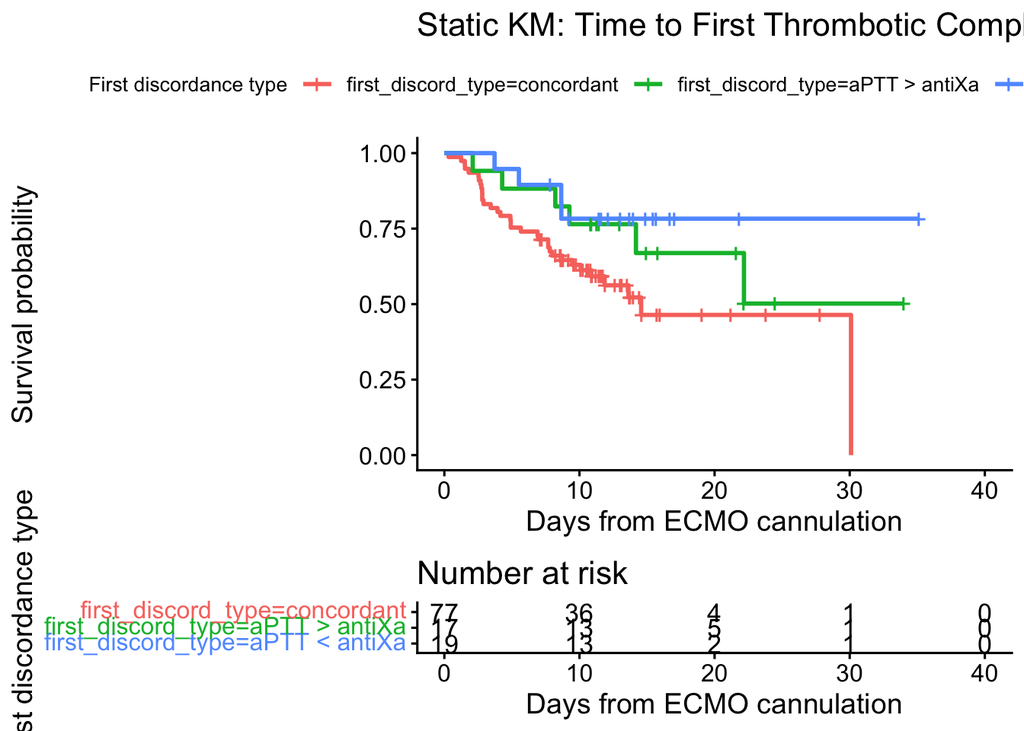

```
## Ignoring unknown labels:
## • colour : "First discordance type"
```

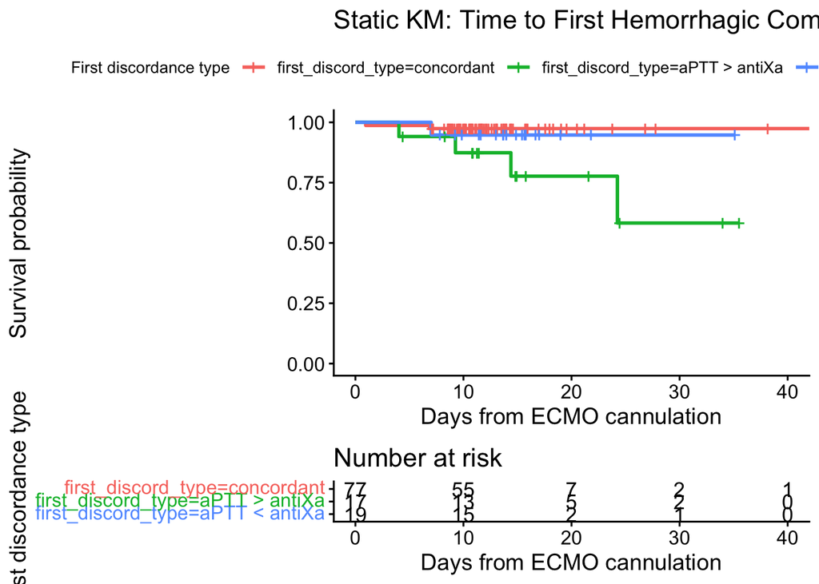

## 2.4 Time-varying exposure: everyone starts concordant, then switches at first discordance

Time-varying thrombosis data: group membership at time 0

| discord_group | n |
| --- | --- |
| concordant | 113 |

Time-varying bleeding data: group membership at time 0

| discord_group | n |
| --- | --- |
| concordant | 113 |

## 2.5 KM curves with time-varying discordance - not reporting this section as need custom risk tables

```
## Ignoring unknown labels:
## • colour : "Strata"
```

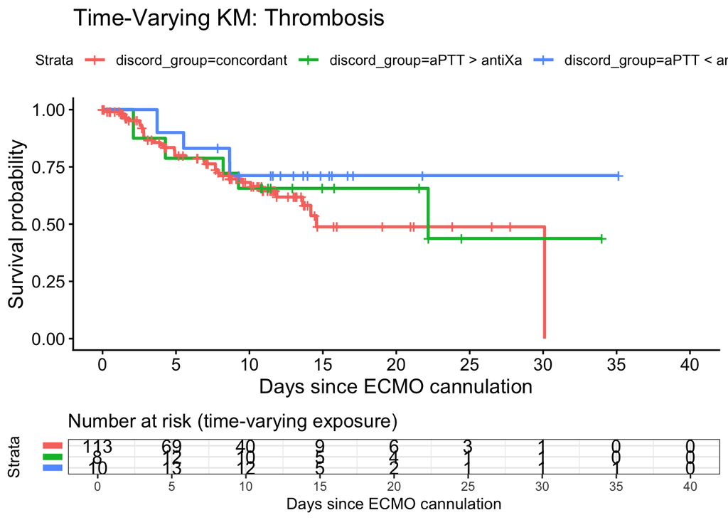

```
## Ignoring unknown labels:
## • colour : "Strata"
```

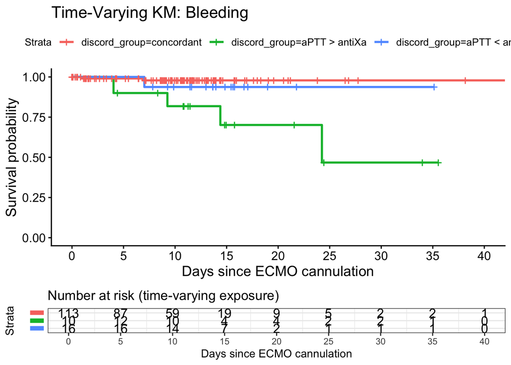

## Reason why number at risk is mis-counting patients

This is not a bug in your build_tvd() — it’s a quirk/limitation of how survfit() computes n.risk at exact cutpoints for multi-state/time-dependent strata (and then ggsurvplot() faithfully prints it).

In other words:

Your data: everyone concordant at time 0 ✅

survfit(summary, times=0): internally classifies some people as discordant at 0 ❌

Your plotted risk table: prints that internal n.risk ❌

Why survfit() does this

It’s almost always an endpoint convention problem with start–stop intervals at t = 0 combined with stratum assignment.

Even though your discordant intervals start at t_disc_days = 1 minute, survfit()’s internal machinery for n.risk at an exact timepoint can behave like:

include intervals with start <= t and include strata membership for subjects who have a later interval beginning “almost immediately”

OR it uses a subject-level “current stratum at t” routine that’s not robust at t=0 when subjects have multiple rows

## 2.5.1 - time varying KM plots w custom risk tables which accurately capture number at risk

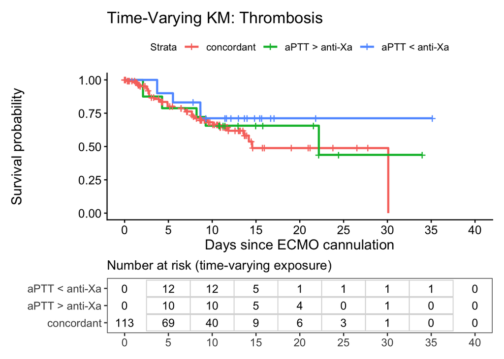

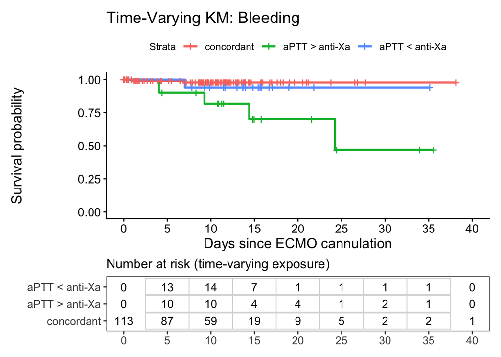

## 2.6 Time-varying Cox models with labs captured at the moment discordance is defined

## PRIMARY RESULTS

Here we:

- Define an **index time** per patient:
  - if discordant: first_discord_time
  - else (always concordant): first paired aPTT/anti-Xa lab_result_time

Time distance (hours) between index time and covariate values used for Cox adjustment

| covariate | n_patients | median_time_h | p95_time_h | max_time_h |
| --- | --- | --- | --- | --- |
| Bilirubin | 113 | 0.43 | 10.00 | 17.15 |
| Heparin dose | 113 | 0.00 | 0.00 | 0.00 |
| INR | 110 | 0.00 | 10.09 | 23.23 |
| Platelet | 112 | 0.46 | 4.38 | 10.63 |

Patients with covariate time gap > 48h (nearest per covariate to index_time)

| mrn |
| --- |

Thrombosis TV data: intervals by discordance group (with indexed labs)

| discord_group | n |
| --- | --- |
| concordant | 109 |
| aPTT > antiXa | 15 |
| aPTT < antiXa | 18 |

Bleeding TV data: intervals by discordance group (with indexed labs)

| discord_group | n |
| --- | --- |
| concordant | 109 |
| aPTT > antiXa | 16 |
| aPTT < antiXa | 18 |

Time-varying Cox model (thrombosis), univariable

| term | std.error | robust.se | statistic | p.value | conf.low | conf.high | HR | p_fdr | p_holm | p_bonf |
| --- | --- | --- | --- | --- | --- | --- | --- | --- | --- | --- |
| discord_groupaPTT > antiXa | 0.5435761 | 0.5182637 | -0.7585560 | 0.4481182 | 0.2444095 | 1.863854 | 0.6749396 | 0.4481182 | 0.8643128 | 0.8962364 |
| discord_groupaPTT < antiXa | 0.5409139 | 0.5615219 | -0.7855069 | 0.4321564 | 0.2140294 | 1.933793 | 0.6433416 | 0.4481182 | 0.8643128 | 0.8643128 |

Time-varying Cox model (thrombosis): HR with N patients contributing per term (n / total)

| term | n_display | std.error | robust.se | statistic | p.value | conf.low | conf.high | n_patients | n_total | HR | p_fdr | p_holm | p_bonf |
| --- | --- | --- | --- | --- | --- | --- | --- | --- | --- | --- | --- | --- | --- |
| discord_groupaPTT > antiXa | NA / NA | 0.571 | 0.540 | -0.611 | 0.541 | 0.249 | 2.073 | NA | NA | 0.719 | 0.756 | 1 | 1 |
| discord_groupaPTT < antiXa | NA / NA | 0.571 | 0.607 | -0.457 | 0.648 | 0.230 | 2.491 | NA | NA | 0.758 | 0.756 | 1 | 1 |
| nearest_inr | 109 / 109 | 0.637 | 0.690 | 1.060 | 0.289 | 0.537 | 8.032 | 109 | 109 | 2.077 | 0.654 | 1 | 1 |
| nearest_bilirubin | 109 / 109 | 0.152 | 0.177 | -1.131 | 0.258 | 0.578 | 1.158 | 109 | 109 | 0.818 | 0.654 | 1 | 1 |
| nearest_platelet | 109 / 109 | 0.003 | 0.003 | 0.189 | 0.850 | 0.994 | 1.007 | 109 | 109 | 1.001 | 0.850 | 1 | 1 |
| heparin_infusion_dose_value_units_kg_hr | 109 / 109 | 0.039 | 0.042 | -1.006 | 0.314 | 0.883 | 1.041 | 109 | 109 | 0.959 | 0.654 | 1 | 1 |
| weight | 109 / 109 | 0.007 | 0.006 | -0.889 | 0.374 | 0.984 | 1.006 | 109 | 109 | 0.995 | 0.654 | 1 | 1 |

Time-varying Cox model (hemorrhage), univariable

| term | std.error | robust.se | statistic | p.value | conf.low | conf.high | HR | p_fdr | p_holm | p_bonf |
| --- | --- | --- | --- | --- | --- | --- | --- | --- | --- | --- |
| discord_groupaPTT > antiXa | 0.9309055 | 0.7986824 | 3.378016 | 0.0007301 | 3.1036329 | 71.04765 | 14.849439 | 0.0014602 | 0.0014602 | 0.0014602 |
| discord_groupaPTT < antiXa | 1.2589542 | 1.1919864 | 1.025546 | 0.3051058 | 0.3283044 | 35.11706 | 3.395451 | 0.3051058 | 0.3051058 | 0.6102116 |

Time-varying Cox model (bleeding): HR with N patients contributing per term (n / total)

| term | n_display | std.error | robust.se | statistic | p.value | conf.low | conf.high | n_patients | n_total | HR | p_fdr | p_holm | p_bonf |
| --- | --- | --- | --- | --- | --- | --- | --- | --- | --- | --- | --- | --- | --- |
| discord_groupaPTT > antiXa | NA / NA | 1.014 | 1.005 | 2.530 | 0.011 | 1.774 | 91.194 | NA | NA | 12.720 | 0.080 | 0.08 | 0.08 |
| discord_groupaPTT < antiXa | NA / NA | 1.394 | 1.294 | 0.673 | 0.501 | 0.189 | 30.140 | NA | NA | 2.388 | 0.827 | 1.00 | 1.00 |
| nearest_inr | 109 / 109 | 1.673 | 1.542 | 0.218 | 0.827 | 0.068 | 28.721 | 109 | 109 | 1.399 | 0.827 | 1.00 | 1.00 |
| nearest_bilirubin | 109 / 109 | 0.302 | 0.233 | 0.275 | 0.784 | 0.675 | 1.684 | 109 | 109 | 1.066 | 0.827 | 1.00 | 1.00 |
| nearest_platelet | 109 / 109 | 0.009 | 0.008 | 0.523 | 0.601 | 0.989 | 1.020 | 109 | 109 | 1.004 | 0.827 | 1.00 | 1.00 |
| heparin_infusion_dose_value_units_kg_hr | 109 / 109 | 0.084 | 0.067 | 1.098 | 0.272 | 0.944 | 1.228 | 109 | 109 | 1.076 | 0.827 | 1.00 | 1.00 |
| weight | 109 / 109 | 0.023 | 0.019 | -0.558 | 0.577 | 0.954 | 1.027 | 109 | 109 | 0.990 | 0.827 | 1.00 | 1.00 |

```
## # A tibble: 4 × 14
##   term        n_display std.error robust.se statistic p.value conf.low conf.high
##   <chr>       <chr>         <dbl>     <dbl>     <dbl>   <dbl>    <dbl>     <dbl>
## 1 discord_gr… NA / NA     1.00      0.987       2.91  0.00367   2.54      122.
## 2 discord_gr… NA / NA     1.28      1.27        0.813 0.416     0.234      33.5
## 3 nearest_inr 109 / 109   1.57      1.95        0.142 0.887     0.0291     59.8
## 4 nearest_pl… 109 / 109   0.00769   0.00765     0.818 0.414     0.991       1.02
## # ℹ 6 more variables: n_patients <int>, n_total <int>, HR <dbl>, p_fdr <dbl>,
## #   p_holm <dbl>, p_bonf <dbl>
```

Notes: **109 patients in CPH models (of 113 total patients)** - missing INR = 3 - missing platelet = 1

**“Robust standard errors clustered by patient were used to account for within-patient correlation.”**

**Limitations include few hemorrhage events. Thus, risk of type 1 error when interpreting individual terms. Hazard ratios are imprecise**

Median follow-up summary

| metric | value |
| --- | --- |
| Patients in survival cohort | 113 |
| Observed follow-up, days | 12.2 (IQR 5.26) |
| Reverse KM median follow-up for hemorrhage model, days (95% CI) | 12.65 (11.65–13.86) |
| Reverse KM median follow-up for thrombosis model, days (95% CI) | 13.99 (13.03–15.97) |

Time-to-event summaries by first discordance type

| first_discord_type | n_patients | hemorrhage_events | thrombosis_events | time_to_hemorrhage_from_ecmo_days | time_to_thrombosis_from_ecmo_days |
| --- | --- | --- | --- | --- | --- |
| concordant | 77 | 2 | 34 | 3.9 (IQR 2.95) | 4.9 (IQR 5.17) |
| aPTT > antiXa | 17 | 4 | 6 | 11.82 (IQR 8.91) | 8.73 (IQR 7.69) |
| aPTT < antiXa | 19 | 1 | 4 | 7.02 (IQR 0) | 7.08 (IQR 3.58) |

Hemorrhage timing among patients by first discordance subtype

| first_discord_type | n_patients | hemorrhage_events | time_to_hemorrhage_from_ecmo_days | time_from_first_discordance_to_hemorrhage_days |
| --- | --- | --- | --- | --- |
| aPTT > antiXa | 17 | 4 | 11.82 (IQR 8.91) | 6.98 (IQR 1.96) |
| aPTT < antiXa | 19 | 1 | 7.02 (IQR 0) | 3.14 (IQR 0) |

# REGRESSION DIAGNOSTICS

## Proportional Hazards Assumption

```
##               chisq df    p
## discord_group 0.597  2 0.74
## GLOBAL        0.597  2 0.74
```

```
##               chisq df    p
## discord_group 0.883  2 0.64
## GLOBAL        0.883  2 0.64
```

```
##                                          chisq df    p
## discord_group                           0.4339  2 0.80
## nearest_inr                             0.3523  1 0.55
## nearest_bilirubin                       0.0423  1 0.84
## nearest_platelet                        0.5868  1 0.44
## heparin_infusion_dose_value_units_kg_hr 0.2814  1 0.60
## weight                                  0.3902  1 0.53
## GLOBAL                                  2.1700  7 0.95
```

```
##                                         chisq df     p
## discord_group                           0.945  2 0.623
## nearest_inr                             4.427  1 0.035
## nearest_bilirubin                       2.228  1 0.136
## nearest_platelet                        1.849  1 0.174
## heparin_infusion_dose_value_units_kg_hr 0.617  1 0.432
## weight                                  0.509  1 0.476
## GLOBAL                                  8.151  7 0.319
```

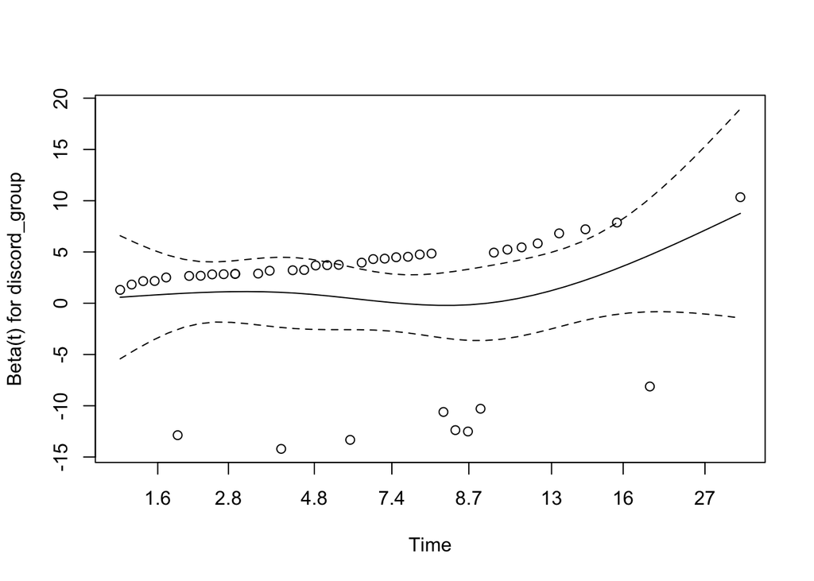

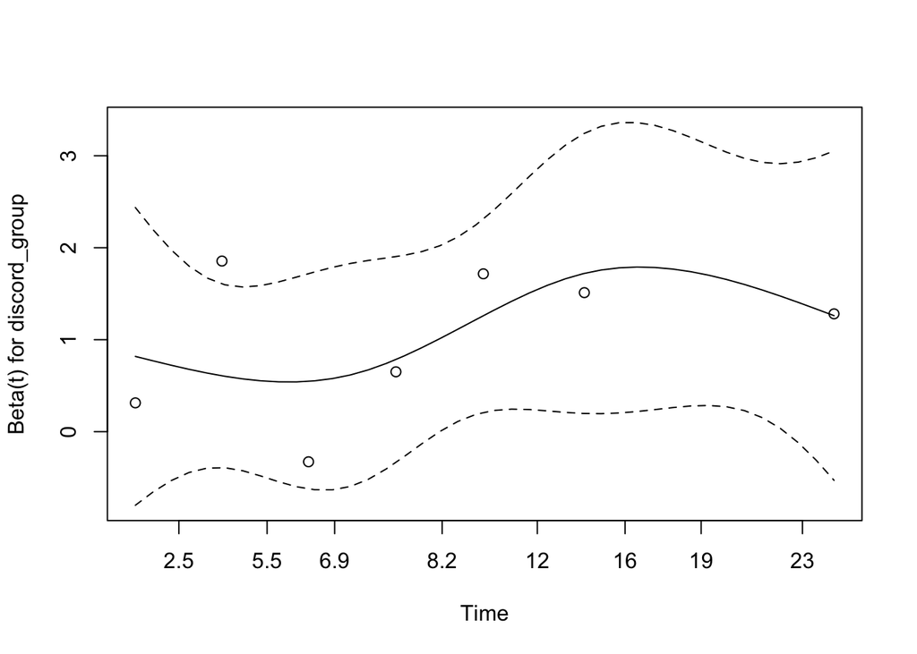

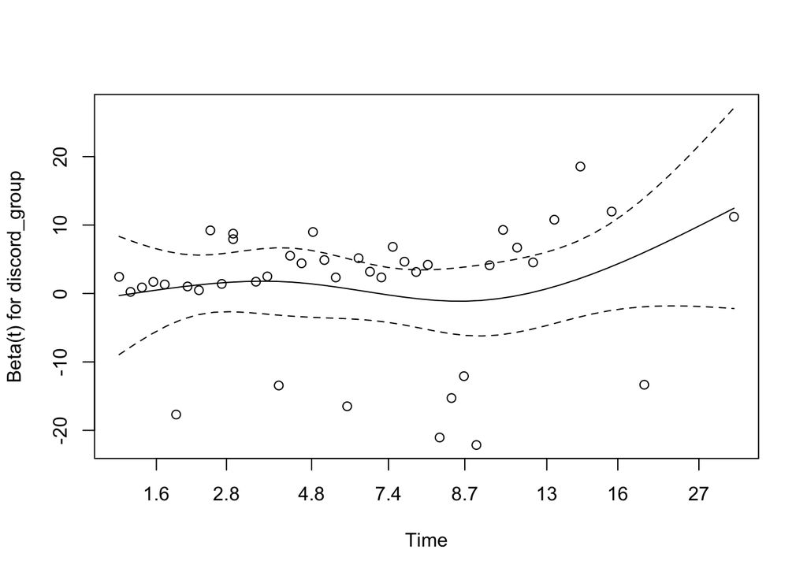

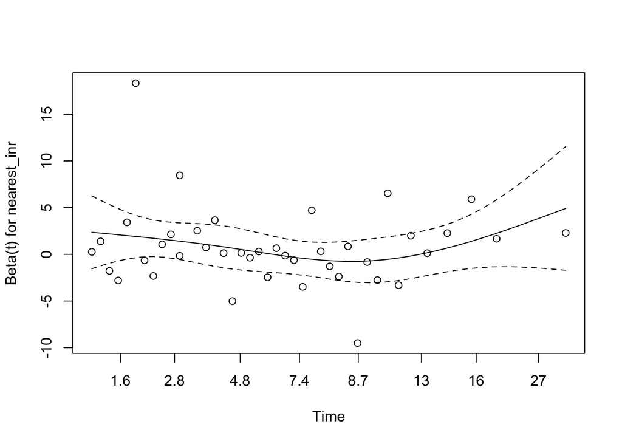

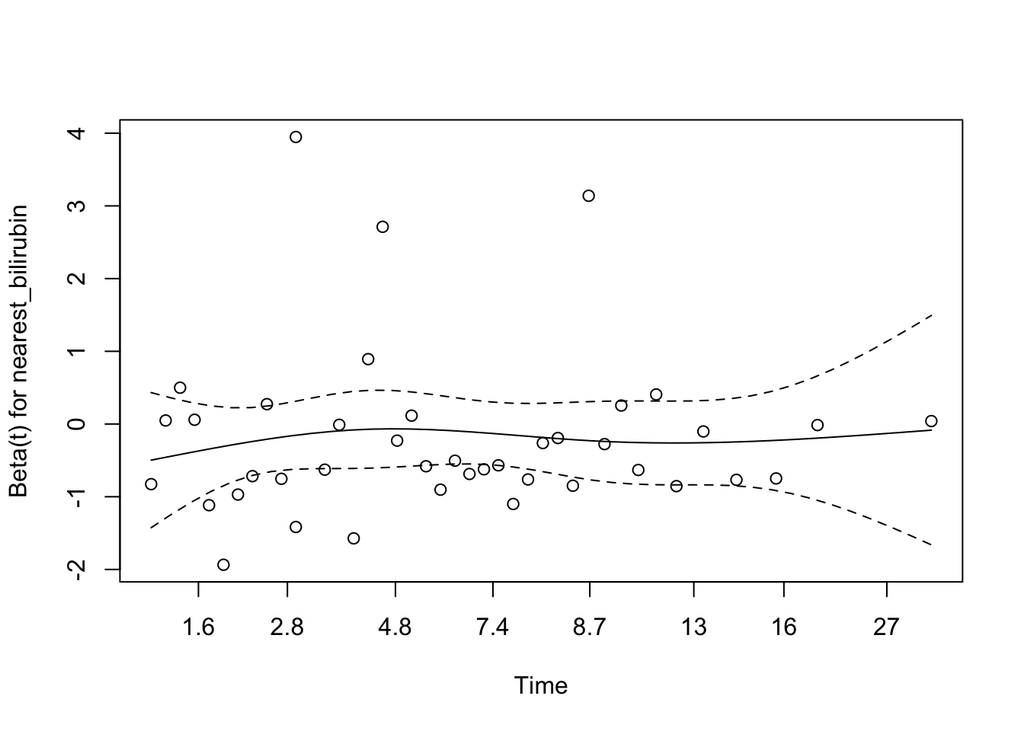

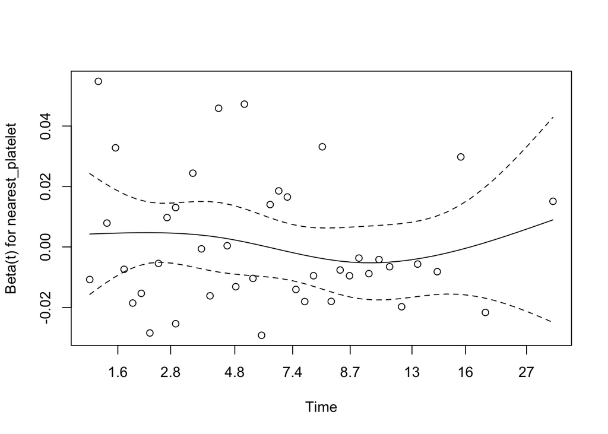

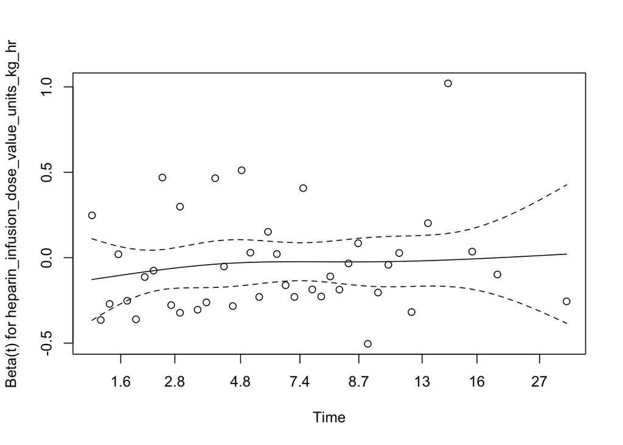

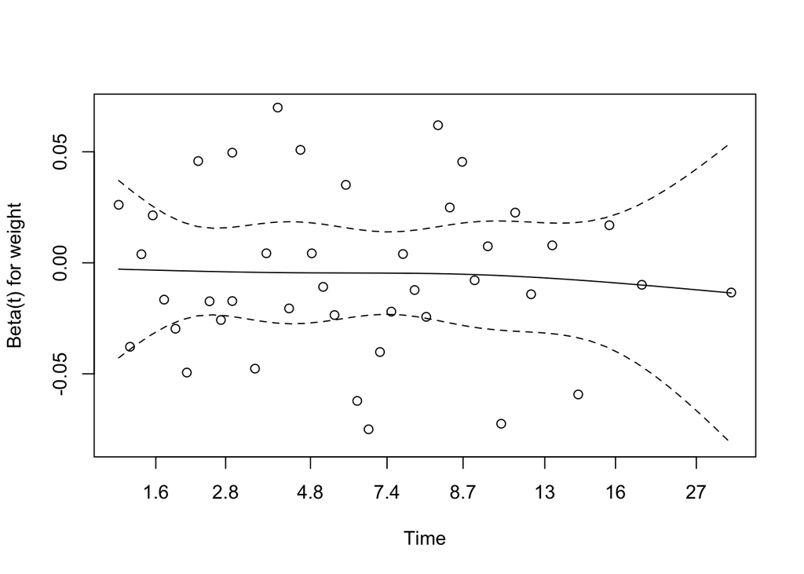

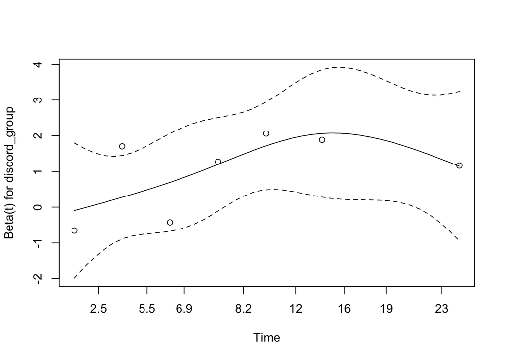

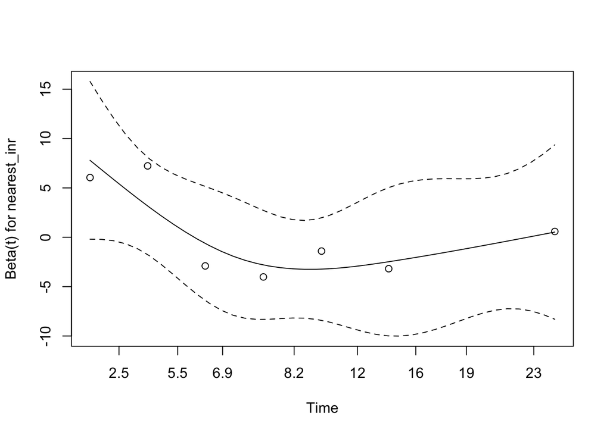

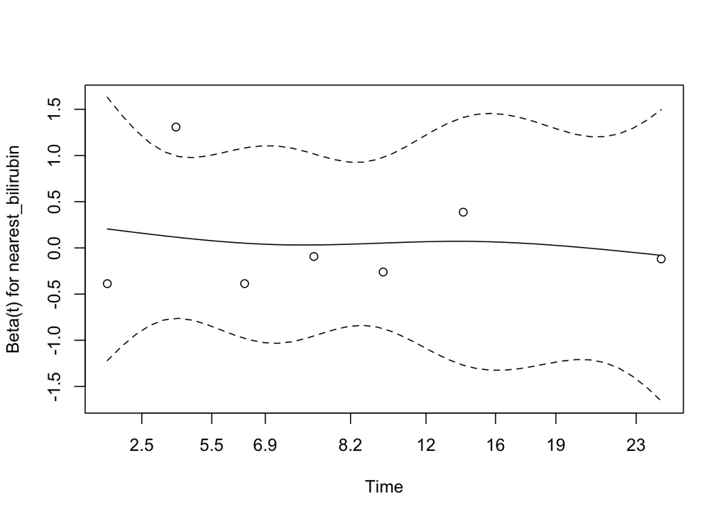

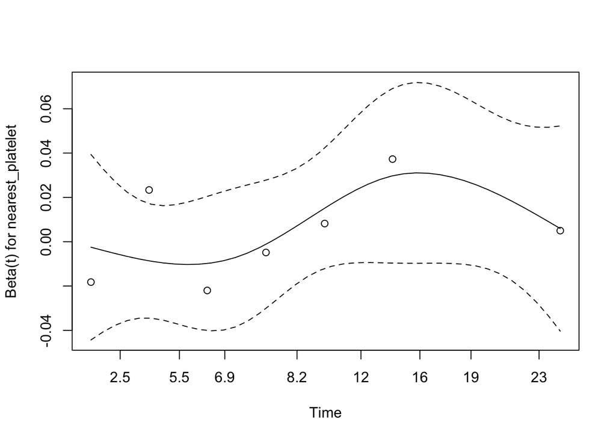

[2 more figures not shown]

How to interpret (exploratory framing)

Global test p > 0.05 → no strong evidence PH violated

Term-level p < 0.05 → possible time-varying effect

Mild violations are acceptable in exploratory analyses if acknowledged

**No strong global violations of the proportional hazards assumption were observed with either model as assessed with Schoenfeld residuals. In the hemorrhage model, INR demonstrated mild non-proportionally (chi square 4.427, p = 0.035), hazard ratios should therefore be interpreted for this covariable as time-averaged effects.**

(i.e. INR impact is a blend of effects over time, and is not always equal throughout the time on ECMO)

## Multicollinearity

*need to fit model without clustering* *model with max covariables checked*

```r
library(car)
# thrombosis
cox_thrombosis_nocluster <- coxph(
  Surv(start, stop, event) ~
    discord_group +
    nearest_inr +
    nearest_bilirubin +
    nearest_platelet +
    heparin_infusion_dose_value_units_kg_hr +
    weight,
  data = tv_thrombosis_indexed)

vif(cox_thrombosis_nocluster)
```

```
##                                             GVIF Df GVIF^(1/(2*Df))
## discord_group                           1.249233  2        1.057209
## nearest_inr                             1.206933  1        1.098605
## nearest_bilirubin                       1.257274  1        1.121282
## nearest_platelet                        1.206480  1        1.098399
## heparin_infusion_dose_value_units_kg_hr 1.142991  1        1.069108
## weight                                  1.137082  1        1.066340
```

```r
# hemorrhage
cox_bleed_nocluster <- coxph(
  Surv(start, stop, event) ~
    discord_group +
    nearest_inr +
    nearest_bilirubin +
    nearest_platelet +
    heparin_infusion_dose_value_units_kg_hr +
    weight,
  data = tv_bleeding_indexed)

vif(cox_bleed_nocluster)
```

```
##                                             GVIF Df GVIF^(1/(2*Df))
## discord_group                           1.670524  2        1.136876
## nearest_inr                             1.365006  1        1.168335
## nearest_bilirubin                       1.496136  1        1.223166
## nearest_platelet                        1.658544  1        1.287845
## heparin_infusion_dose_value_units_kg_hr 1.478066  1        1.215757
## weight                                  1.440772  1        1.200322
```

**VIF ≈ 1–2 → no concern**

## Influence / outliers (DFBETA)

```
## [1] 0.264947402 0.273640069 0.386392297 0.095695415 0.001307056 0.016792951
## [7] 0.001938324
```

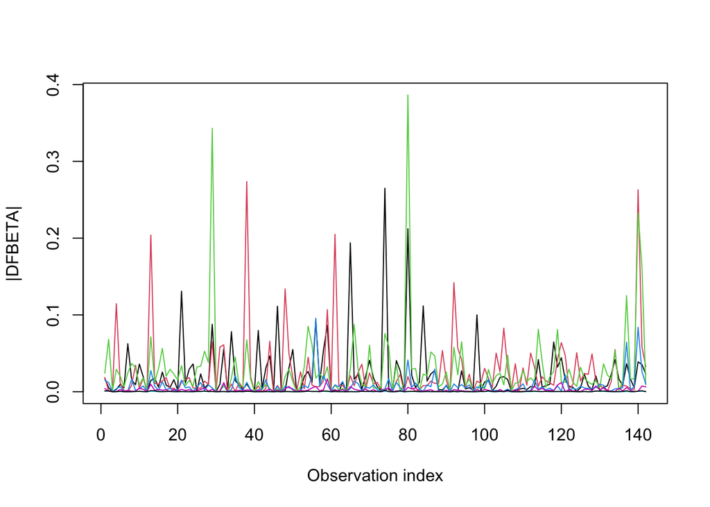

```
## [1] 0.585135025 1.029875644 0.891290457 0.179056666 0.003483407 0.039208687
## [7] 0.010884140
```

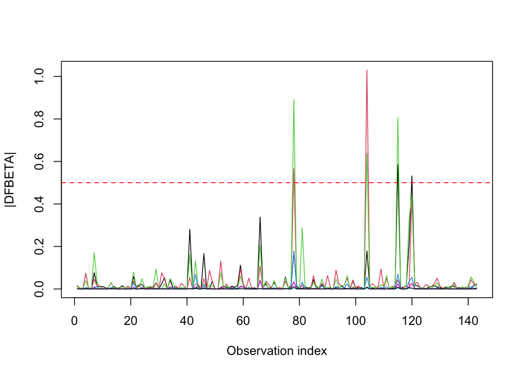

Interpretation

|DFBETA| > ~0.5 suggests influential individuals

## Martingale residuals

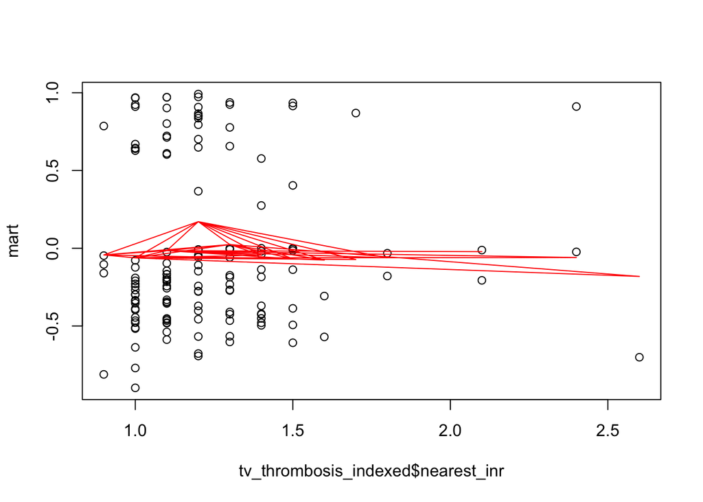

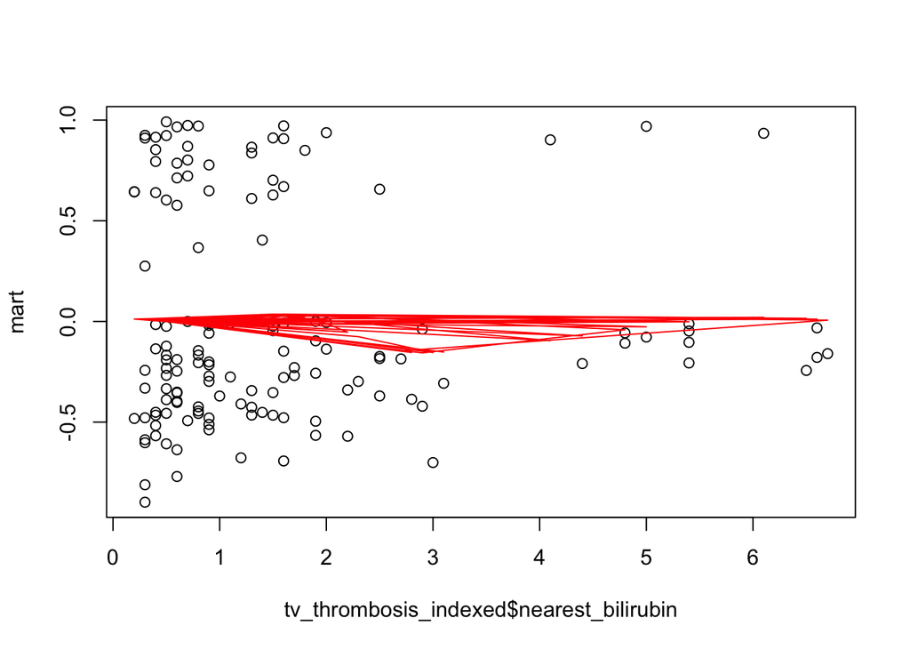

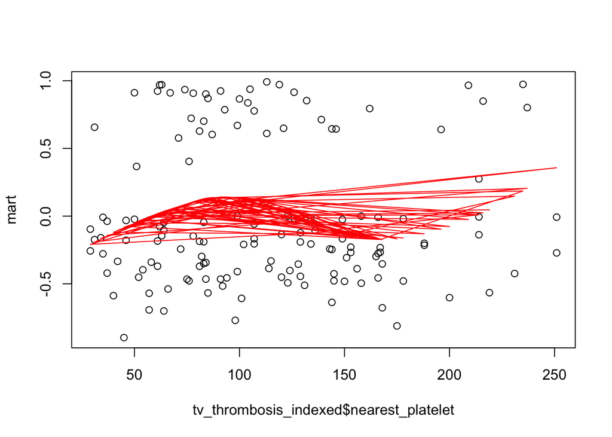

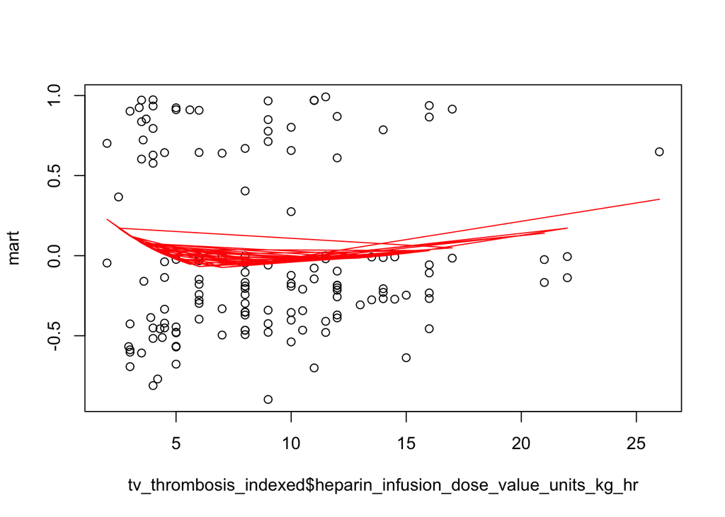

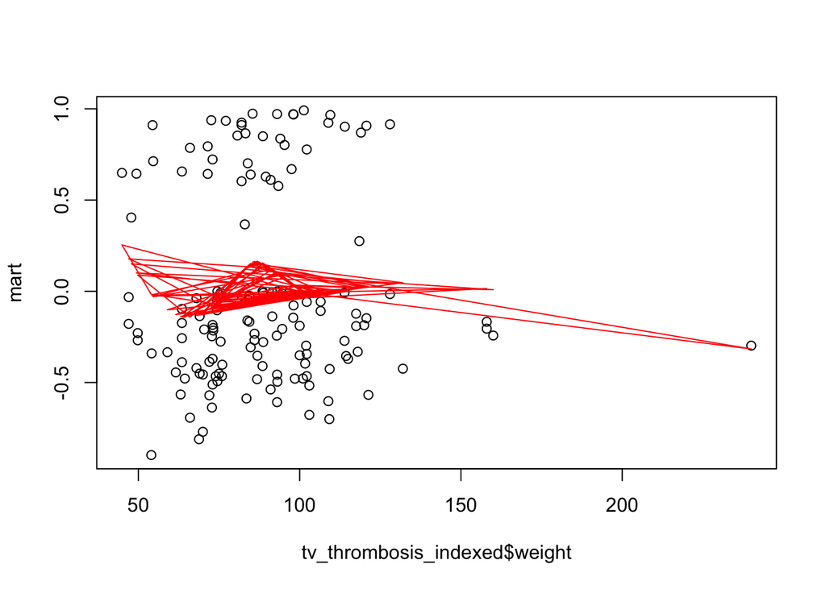

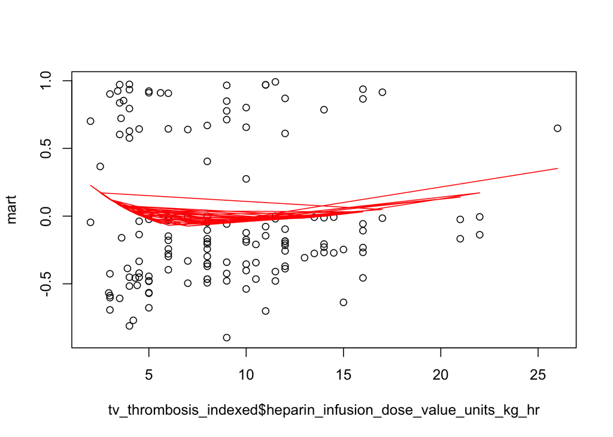

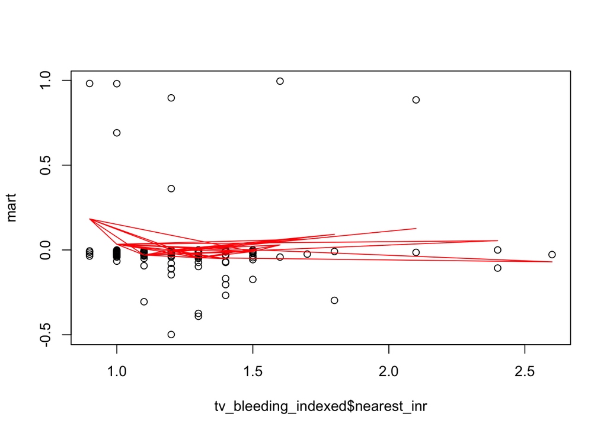

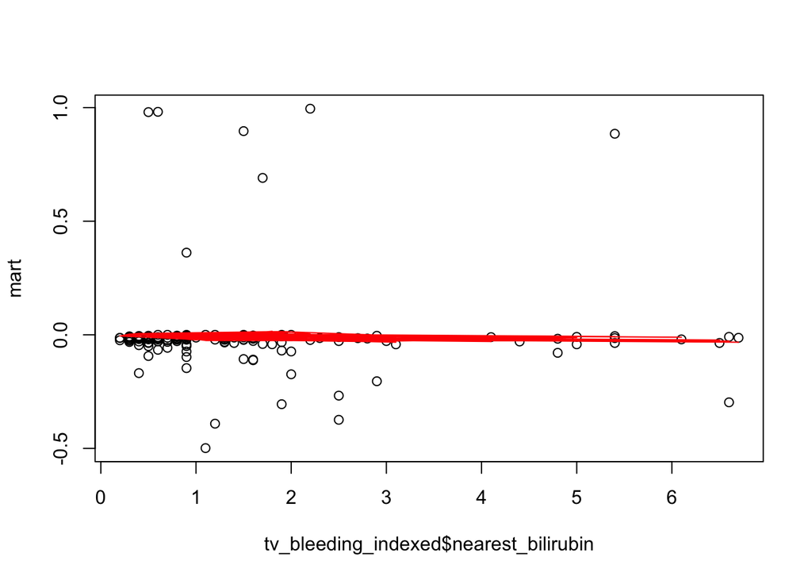